# Solutions to Chapter 4 Exercises

Howard Baek

Last compiled on September 08, 2021

### 4.5 Exercises

1. Draw a boxplot of `hwy` for each value of `cyl`, without turning `cyl` into a factor. What extra aesthetic do you need to set?

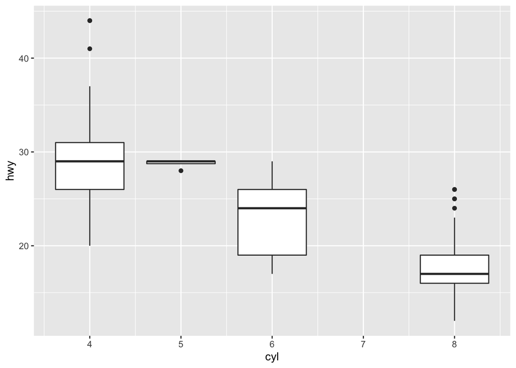

```r
mpg %>%
  ggplot(aes(cyl, hwy, group = cyl)) +
  geom_boxplot()
```

- Since the variable `cyl` is an integer, you need to set `group = cyl`. According to the [ggplot2 docs](https://ggplot2.tidyverse.org/reference/aes_group_order.html), “when no discrete variable is used in the plot, you will need to explicitly define the grouping structure by mapping group to a variable that has a different value for each group.”
2. Modify the following plot so that you get one boxplot per integer value of `displ`.

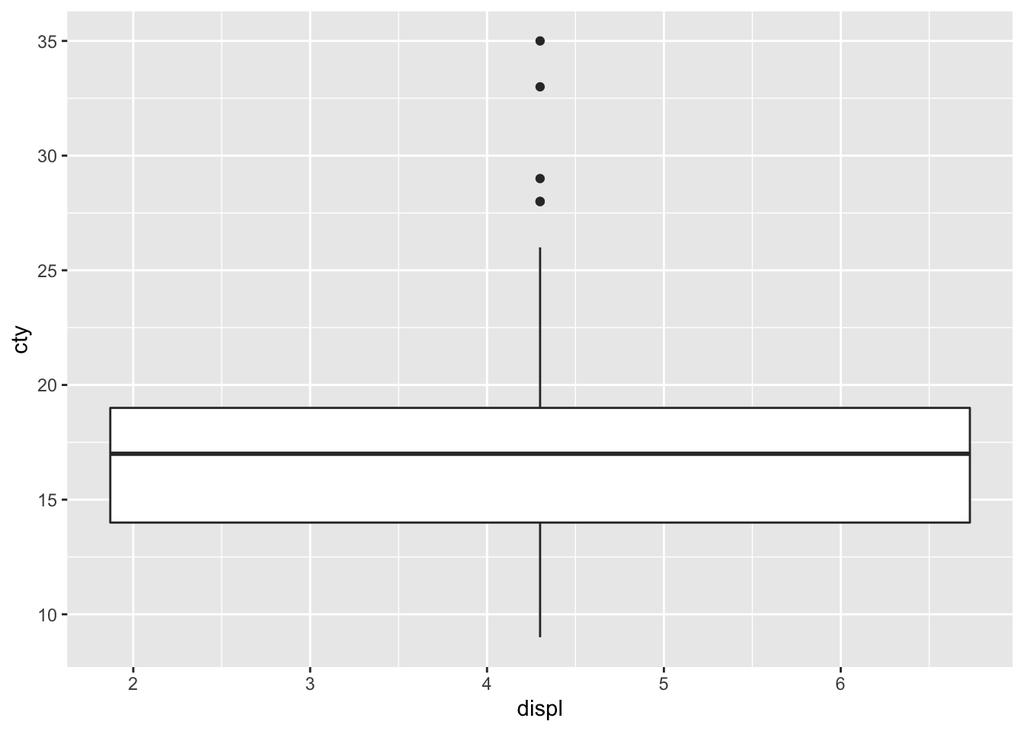

```r
ggplot(mpg, aes(displ, cty)) +
  geom_boxplot()
```

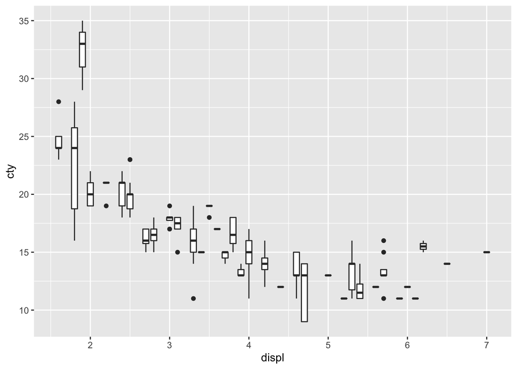

```r
ggplot(mpg, aes(displ, cty, group = displ)) +
  geom_boxplot()
```

3. When illustrating the difference between mapping continuous and discrete colours to a line, the discrete example needed `aes(group = 1)`. Why? What happens if that is omitted? What’s the difference between `aes(group = 1)` and `aes(group = 2)`? Why?
- Let’s examine the example in the book:

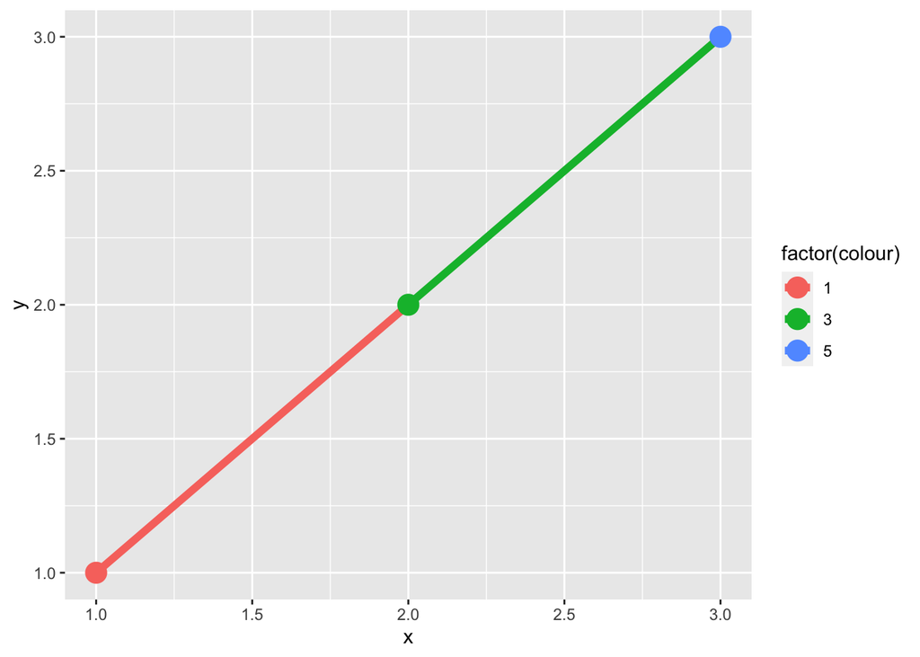

```r
df <- data.frame(x = 1:3, y = 1:3, colour = c(1,3,5))

ggplot(df, aes(x, y, colour = factor(colour))) +
  geom_line(aes(group = 2), size = 2) +
  geom_point(size = 5)
```

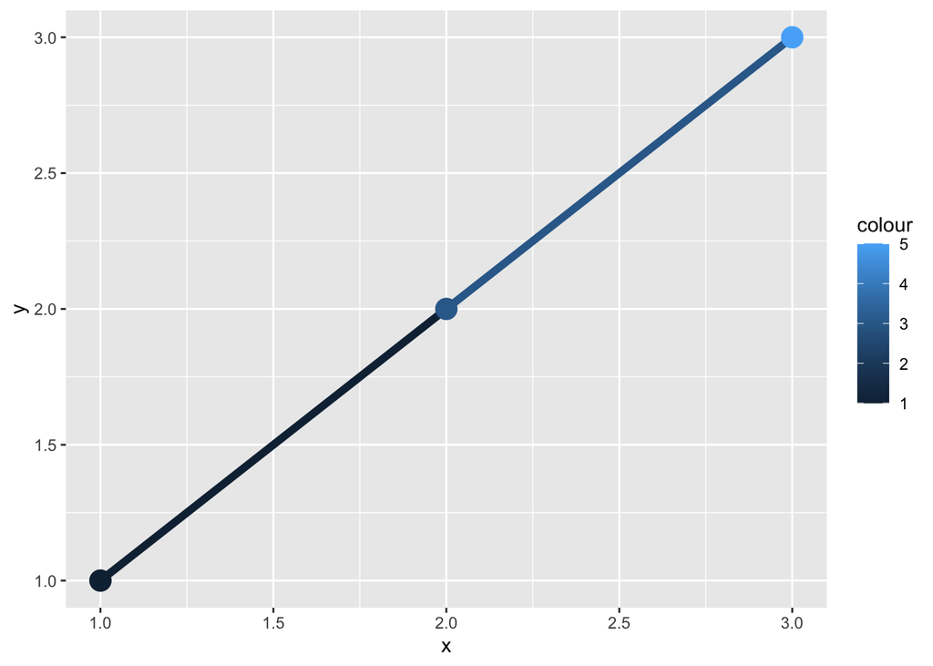

```r
ggplot(df, aes(x, y, colour = colour)) +
  geom_line(aes(group = 1), size = 2) +
  geom_point(size = 5)
```

- When omitted, we don’t get a line that connects all these points. In fact, we get a message saying “geom_path: Each group consists of only one observation. Do you need to adjust the group aesthetic?” This happens because we included the colour aesthetic and made each color include only one observation. In order to tell ggplot that all these points are in the same group, we need to include `aes(group = 1)`. It doesn’t matter what group is equal to. As long as we include all the points in the same group, we should be able to connect the points with a line.
4. How many bars are in each of the following plots?

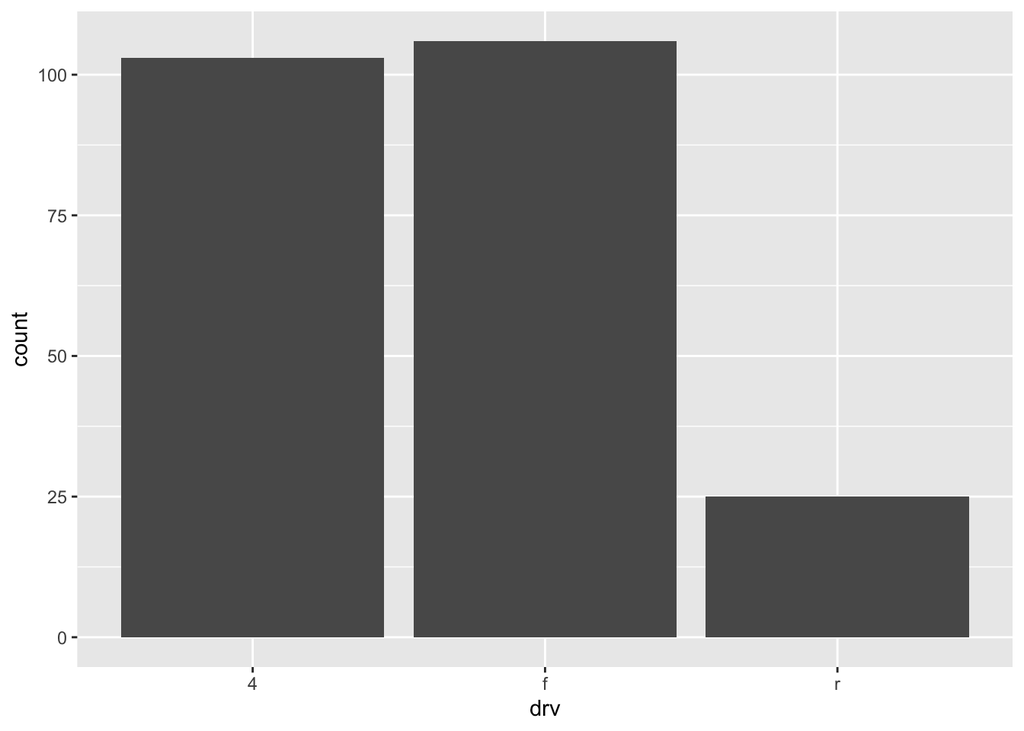

```r
ggplot(mpg, aes(drv)) +
      geom_bar()
```

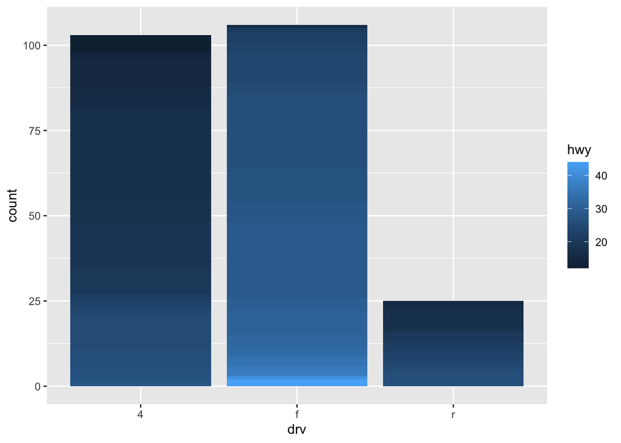

```r
# There are 3 bars in this plot.


ggplot(mpg, aes(drv, fill = hwy, group = hwy)) +
  geom_bar()
```